# Rによる日本語テキスト処理2

## データの準備

1. まず練習用テキストファイル一式をダウンロード
2. 解凍し、フォルダと中身を確認
3. 一部（森鴎外『雁』）を表示させてみる

`download`命令にURLとファイル名を指定することでダウンロード

```r
# 念のため保存されることになるフォルダを確認する命令
getwd()
## 以下は、利用しているパソコンに合わせてどちらか1行だけを実行
# Mac/Linux
download.file("http://rmecab.jp/data.zip", destfile = "data.zip")
# Windows
download.file("http://rmecab.jp/dataWIN.zip", destfile = "data.zip")
# 以下共通
unzip("data.zip")#解凍
dir("data")#ファイル・フォルダ一覧を確認
file.show("data/writers/ogai_gan.txt")
```

## クラスタ分析

夏目漱石と森鴎外それぞれから４作品（ただし冒頭から２万弱文字程度に統一）を分析対象とする

文字のバイグラムのテキストの類似度（擬似的に文体と考える）で分類

考え方：

1. ある文字と別の文字がペアで使われている回数が近いテキストは似ているはず
2. そこで、すべての文字についてペア（バイグラム）の頻度を計測
3. 計測結果から、テキストごとの類似度を計算
4. 類似度の近さからグループ分けする
5. 結果をデンドログラムで表す

分析手順：

1. データ処理、形態素解析機能を使う宣言をする(`library`)
2. `docNgram` を使って文字のバイグラムデータを作成する
3. 末尾`tail`を確認しておく

[output not shown]

[output not shown]

```r
library(dplyr);library(RMeCab)
writers <- docNgram("data/writers/", type = 0)
writers %>% tail()
```

このデータから文書間の距離 `dist` を求めて分類`hclust`し、グラフ`plot`にする

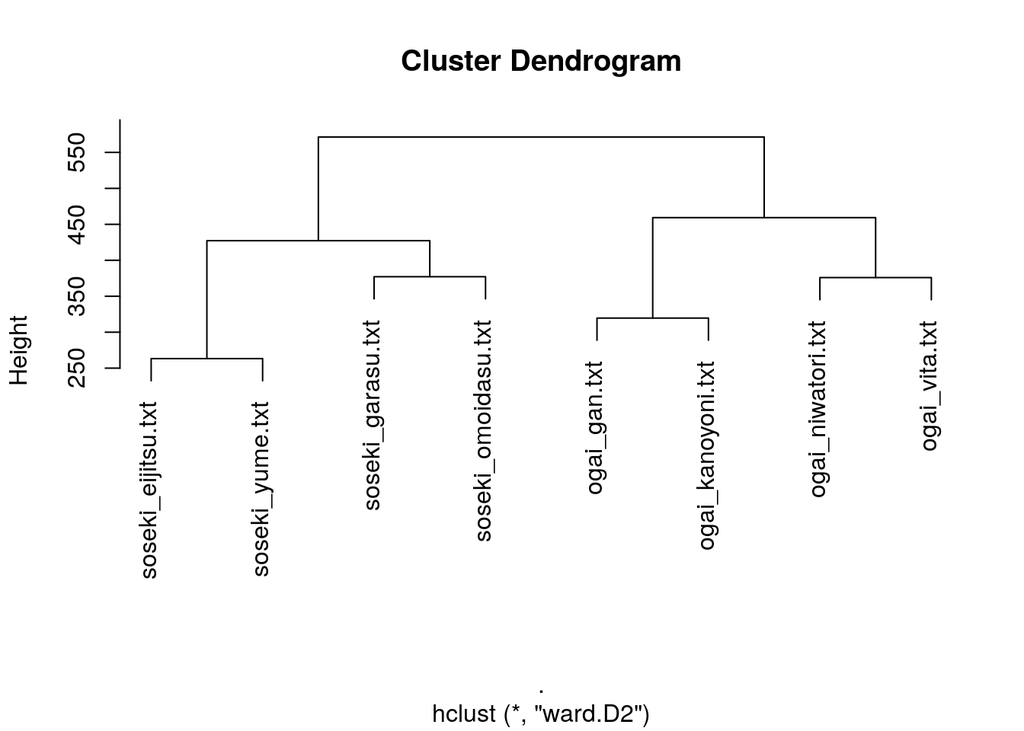

```r
writers %>% t() %>% dist() %>% hclust("ward.D2") %>% plot()
```

## 主成分分析

上で求めた文字のバイグラムデータから、助詞（文字）と読点のペア８種だけを使っても分類できる

考え方：

1. 8つの助詞－読点ペアと、それぞれの頻度を表すデータに圧縮という処理を施し、2種類の数値（主成分）に変換してしまう
2. この2つの数値は、テキストごとの近さを擬似的に表現している
3. なので、一つを横軸、もう一つを縦軸にとったグラフ（バイプロット）を描くことで分類が可能

作業手順：

1. 行に名前がついているので、冒頭１０行を確認(`rownames`)
2. 指定した「文字と読点」の組み合わせだけを残す
3. 主成分分析というデータ要約機能を適用(`princomp`)
4. バイプロットというグラフを生成`bibplot`

```r
rownames(writers) %>% head(10)
```

```
##  [1] "[―-―]" "[―-「]" "[―-あ]" "[―-こ]" "[―-ち]" "[―-と]" "[―-も]"
##  [8] "[―-や]" "[―-を]" "[―-永]"
```

```r
writers <- writers[rownames(writers) %in% c("[と-、]", "[て-、]", "[は-、]", "[が-、]",
                                  "[で-、]", "[に-、]", "[ら-、]", "[も-、]"),  ]
# データを確認
writers
```

```
##          Text
## Ngram     ogai_gan.txt ogai_kanoyoni.txt ogai_niwatori.txt ogai_vita.txt
##   [が-、]           66                66                48            63
##   [て-、]          167               194               135           112
##   [で-、]           67                52                76            53
##   [と-、]           47                34                29            36
##   [に-、]           55                81                36            47
##   [は-、]           73                67                35            69
##   [も-、]           10                25                14            21
##   [ら-、]           44                34                37            35
##          Text
## Ngram     soseki_eijitsu.txt soseki_garasu.txt soseki_omoidasu.txt
##   [が-、]                 31                28                  38
##   [て-、]                143                70                 102
##   [で-、]                 37                36                  46
##   [と-、]                 86                24                  29
##   [に-、]                 41                41                  32
##   [は-、]                 40                39                  42
##   [も-、]                 22                10                  18
##   [ら-、]                 51                33                  28
##          Text
## Ngram     soseki_yume.txt
##   [が-、]              33
##   [て-、]             138
##   [で-、]              38
##   [と-、]              41
##   [に-、]              39
##   [は-、]              22
##   [も-、]              13
##   [ら-、]              44
```

主成分分析命令`princomp`を実行して保存し(`writers_pc`)、グラフで確認する`biplot`

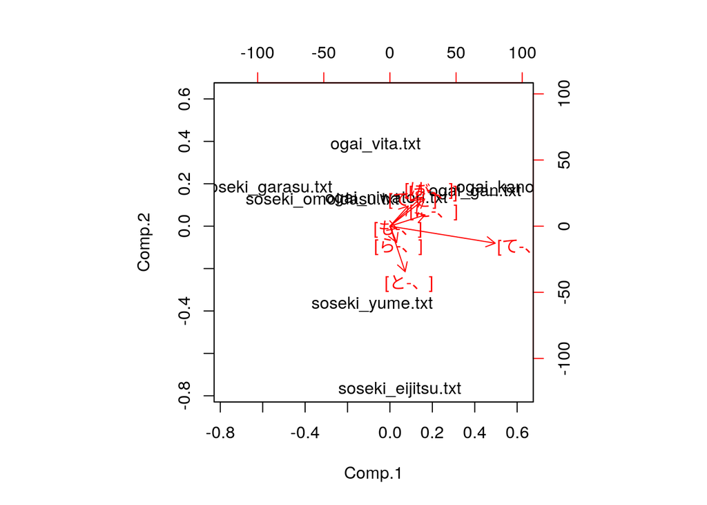

```r
writers_pc <- writers %>% t() %>% princomp()
biplot(writers_pc)
```

## 複雑なデータ操作

分析の手法に合わせてデータを整理、加工する処理が多くなる

## アンケート分析

```r
okinawa <- read.csv("data/H18koe.csv")#最後の指定で文字列に特殊なコードを加えない
# 冒頭を確認
okinawa %>% head()
```

```
##                                                                                                                                                                                                                                                                           Opinion
## 1                                                                                                                                                                                                                    海岸の美化・清掃　　航空運賃を安くする　　那覇の交通渋滞緩和
## 2 花粉で悩んでいますので、今回過去に訪れて思い切り美味しいクシャミの出ない空気を吸えて幸せでした。今後花粉の時季に3ヶ月くらいを目途に滞在を考えております。そういう宿泊施設の宣伝等ありましたら、観光情報とともにインターネットで流していただくと利用しやすく有難く思っています。
## 3                                                                                        空港→国際通りまでタクシーを利用。乗車したらどちらまで、下車したらありがとうございますの基本動作が全く無い。沖縄の観光のためにもお客様に気持ちよく帰ってもらう為にも教育をした方が良い。
## 4                                                                                                  気候が暖かくて住みやすく、沖縄の人たちは名古屋人と違ってのんびりしていて楽しい。車もせかす人もいなく運転しやすかった。今回友達と来たけど、次回は母と一緒に遊びに行きたいです。
## 5                                                                                                            今回の旅行では連日観光バスを利用した中で、ガイドさんの案内や対応が素晴らしく感銘しました。このようなことが一層沖縄のイメージをアップさせていくことだと思われました。
## 6                                                                                                                                                                                                                                            国道の渋滞が解消されると移動に便利。
##   Region  Sex    Age    Satis
## 1   関東 男性 ３０代 やや満足
## 2   関東 女性 ６０代 やや満足
## 3   関東 男性 ５０代 やや満足
## 4   中部 女性 ２０代 大変満足
## 5   近畿 男性 ６０代 大変満足
## 6   関東 女性 ２０代 やや満足
```

性別と年齢別に意見の相違を知りたい

- 性別と年齢でデータを分ける
- それぞれの「感想(`opinion`)」をまとめる
- 分類された感想ごとに頻度表を作成
- 性別・年代別の頻度表を比較する

データ操作：

1. 年代の分け方（水準`levels`）を確認
2. それぞれの回答数を確認(`filter`)
3. 回答数が極端に少ない場合の処理
4. 性別と年代の組み合わせごとに意見ファイルを作成

```r
## 年代の水準を調べる
AgeL <- okinawa %>% pull(Age) %>% levels()
AgeL

## 各年代ごとに回答者数を調べる
library(purrr)#同じ処理を年代ごとに繰り返すために必要な追加機能
AgeL %>% map_chr(
  ~ filter(okinawa, Age == .x) %>% NROW()
)
## "１０代"は4人しかいないので、今回は削除
## !=という命令で"１０代"以外を対象年代とする
AgeL <- AgeL[AgeL != "１０代"]
AgeL

## 性別と年齢別に意見を統合し、一時ファイルに保存する
## 保存場所をdata/okinawaとする
#dir.create("okinawa")
## 女性の年代別意見をファイルにする
library(magrittr)
AgeL %>% map(
  ~ filter(okinawa, Age  == .x, Sex == "女性") %>% {
   tmp <- use_series(data = ., Opinion) %>% as.character()
   writeLines(text = tmp, con = paste0("okinawa/F", (2:7)[AgeL == .x], "0.txt"))
  }
)

## 男性の年代別意見をファイルにする
AgeL %>% map(
  ~ filter(okinawa, Age  == .x, Sex == "男性") %>% {
   tmp <-  use_series(data = ., Opinion) %>% as.character()
   writeLines(text = tmp, con = paste0("okinawa/M", (2:7)[AgeL == .x], "0.txt"))
  }
)
## フォルダの中身を確認してみる
dir("okinawa")
```

```r
## 年代の水準を調べる
AgeL <- okinawa %>% pull(Age) %>% levels()
AgeL

## 各年代ごとに回答者数を調べる
library(purrr)#同じ処理を年代ごとに繰り返すために必要な追加機能
AgeL %>% map_chr(
  ~ filter(okinawa, Age == .x) %>% NROW()
)
## "１０代"は4人しかいないので、今回は削除
## !=という命令で"１０代"以外を対象年代とする
AgeL <- AgeL[AgeL != "１０代"]
AgeL

## 性別と年齢別に意見を統合し、一時ファイルに保存する
## 保存場所をdata/okinawaとする
#dir.create("okinawa")
## 女性の年代別意見をファイルにする
library(magrittr)
dir.create("/myBackup/temp/okinawa/F")
AgeL %>% map(
  ~ filter(okinawa, Age  == .x, Sex == "女性") %>% {
   tmp <- use_series(data = ., Opinion) %>% as.character()
   writeLines(text = tmp, con = paste0("/myBackup/temp/okinawa/F", (2:7)[AgeL == .x], "0.txt"))
  }
)

## 男性の年代別意見をファイルにする
dir.create("/myBackup/temp/okinawa/M")

AgeL %>% map(
  ~ filter(okinawa, Age  == .x, Sex == "男性") %>% {
   tmp <-  use_series(data = ., Opinion) %>% as.character()
   writeLines(text = tmp, con = paste0("/myBackup/temp/okinawa/M", (2:7)[AgeL == .x], "0.txt"))
  }
)
## フォルダの中身を確認してみる
dir("okinawa")
```

1. ファイルごとに形態素解析を実行
2. 全体の結果を`FM`として保存

```r
library(RMeCab)
FM <- docDF("okinawa", type = 1,
             pos = c("名詞","動詞","形容詞"))
FM %>% head()
```

```
## file_name =  /home/ishida/Dropbox/R/forCheck_utf8/data/okinawa/F20.txt opened
## file_name =  /home/ishida/Dropbox/R/forCheck_utf8/data/okinawa/F30.txt opened
## file_name =  /home/ishida/Dropbox/R/forCheck_utf8/data/okinawa/F40.txt opened
## file_name =  /home/ishida/Dropbox/R/forCheck_utf8/data/okinawa/F50.txt opened
## file_name =  /home/ishida/Dropbox/R/forCheck_utf8/data/okinawa/F60.txt opened
## file_name =  /home/ishida/Dropbox/R/forCheck_utf8/data/okinawa/F70.txt opened
## file_name =  /home/ishida/Dropbox/R/forCheck_utf8/data/okinawa/M20.txt opened
## file_name =  /home/ishida/Dropbox/R/forCheck_utf8/data/okinawa/M30.txt opened
## file_name =  /home/ishida/Dropbox/R/forCheck_utf8/data/okinawa/M40.txt opened
## file_name =  /home/ishida/Dropbox/R/forCheck_utf8/data/okinawa/M50.txt opened
## file_name =  /home/ishida/Dropbox/R/forCheck_utf8/data/okinawa/M60.txt opened
## file_name =  /home/ishida/Dropbox/R/forCheck_utf8/data/okinawa/M70.txt opened
## number of extracted terms = 1706
## now making a data frame. wait a while!
```

```
##   TERM POS1     POS2 F20.txt F30.txt F40.txt F50.txt F60.txt F70.txt
## 1    ) 名詞 サ変接続       0       0       0       0       0       0
## 2    * 名詞 サ変接続       2       1       0       0       1       3
## 3    . 名詞 サ変接続       1       0       0       1       0       0
## 4    1 名詞       数       1       1       1       1       3       0
## 5   10 名詞       数       0       0       0       0       1       0
## 6   11 名詞       数       0       0       0       0       0       0
##   M20.txt M30.txt M40.txt M50.txt M60.txt M70.txt
## 1       0       0       0       0       1       0
## 2       0       0       0       0       0       0
## 3       0       0       0       0       0       1
## 4       0       0       0       0       0       0
## 5       0       0       0       1       0       1
## 6       0       0       1       0       0       0
```

品詞細分類で絞り込み(`filiter`)、「ある」「いる」などの冗長な語を削除

```r
FM2 <- FM %>% filter(POS2 %in% c("一般", "サ変接続","固有", "自立"))
FM2 <- FM2 %>% filter(! TERM%in% c("ある","いう","いる", "する",
                                   "できる", "なる","思う"))
# 行数（この場合は出現単語の種類に相当）を確認
FM2 %>% NROW()
```

```
## [1] 1277
```

対応分析という方法で意見と属性（性別年齢）の違いを調べてみる

1. 総頻度を参照して、頻度の下限を設定する(`filter(SUMS >= 7)`)

```r
FM2$SUMS <- rowSums(FM2[, -(1:3)])
summary(FM2$SUMS)
```

```
##    Min. 1st Qu.  Median    Mean 3rd Qu.    Max.
##   1.000   1.000   1.000   2.753   2.000 107.000
```

```r
FM3 <- FM2 %>% filter(SUMS >= 7)
FM3 %>% NROW
```

```
## [1] 96
```

```r
colnames((FM3))
```

```
##  [1] "TERM"    "POS1"    "POS2"    "F20.txt" "F30.txt" "F40.txt" "F50.txt"
##  [8] "F60.txt" "F70.txt" "M20.txt" "M30.txt" "M40.txt" "M50.txt" "M60.txt"
## [15] "M70.txt" "SUMS"
```

```r
FM3$TERM
```

```
##  [1] "*"          "いい"       "うれしい"   "ない"       "よい"
##  [6] "わかる"     "イメージ"   "ガイド"     "ゴミ"       "タクシー"
## [11] "ダイビング" "ツアー"     "トイレ"     "バス"       "ホテル"
## [16] "マナー"     "モノレール" "レンタカー" "乗る"       "交通"
## [21] "人"         "住む"       "体験"       "充実"       "入る"
## [26] "出す"       "出来る"     "利用"       "北部"       "印象"
## [31] "古い"       "団体"       "場所"       "多い"       "天気"
## [36] "守る"       "客"         "対応"       "少ない"     "島"
## [41] "市内"       "店"         "悪い"       "情報"       "感じる"
## [46] "感動"       "改善"       "整備"       "文化"       "料理"
## [51] "料金"       "施設"       "旅"         "旅行"       "期待"
## [56] "本島"       "来る"       "案内"       "楽しい"     "標識"
## [61] "残す"       "水族館"     "海"         "渋滞"       "満足"
## [66] "無い"       "環境"       "目立つ"     "県"         "石垣"
## [71] "移動"       "空港"       "素晴らしい" "美"         "美しい"
## [76] "美味しい"   "考える"     "自分"       "良い"       "行う"
## [81] "行く"       "見る"       "観光"       "言う"       "訪れる"
## [86] "買う"       "車"         "運転"       "道"         "道路"
## [91] "離島"       "雨"         "飛行機"     "食べる"     "食事"
## [96] "高い"
```

1. 対応分析を適用するために数字だけのデータを生成

```r
library(stringr)
## 正規表現で数値列だけを取り出す
FM4 <- FM3 %>% select(matches("[FM]\\d\\d"))
## 列名を設定
colnames(FM4) <- str_extract(colnames(FM4), "[FM]\\d\\d")
## 行列の名前を設定
rownames(FM4) <- FM3$TERM
## 次元(行数と列数)を確認
dim(FM4)
```

```
## [1] 96 12
```

```r
## 列名と行名を確認
colnames(FM4)
```

```
##  [1] "F20" "F30" "F40" "F50" "F60" "F70" "M20" "M30" "M40" "M50" "M60"
## [12] "M70"
```

```r
rownames(FM4)
```

```
##  [1] "*"          "いい"       "うれしい"   "ない"       "よい"
##  [6] "わかる"     "イメージ"   "ガイド"     "ゴミ"       "タクシー"
## [11] "ダイビング" "ツアー"     "トイレ"     "バス"       "ホテル"
## [16] "マナー"     "モノレール" "レンタカー" "乗る"       "交通"
## [21] "人"         "住む"       "体験"       "充実"       "入る"
## [26] "出す"       "出来る"     "利用"       "北部"       "印象"
## [31] "古い"       "団体"       "場所"       "多い"       "天気"
## [36] "守る"       "客"         "対応"       "少ない"     "島"
## [41] "市内"       "店"         "悪い"       "情報"       "感じる"
## [46] "感動"       "改善"       "整備"       "文化"       "料理"
## [51] "料金"       "施設"       "旅"         "旅行"       "期待"
## [56] "本島"       "来る"       "案内"       "楽しい"     "標識"
## [61] "残す"       "水族館"     "海"         "渋滞"       "満足"
## [66] "無い"       "環境"       "目立つ"     "県"         "石垣"
## [71] "移動"       "空港"       "素晴らしい" "美"         "美しい"
## [76] "美味しい"   "考える"     "自分"       "良い"       "行う"
## [81] "行く"       "見る"       "観光"       "言う"       "訪れる"
## [86] "買う"       "車"         "運転"       "道"         "道路"
## [91] "離島"       "雨"         "飛行機"     "食べる"     "食事"
## [96] "高い"
```

1. 対応分析を実行する命令`ca`を実行

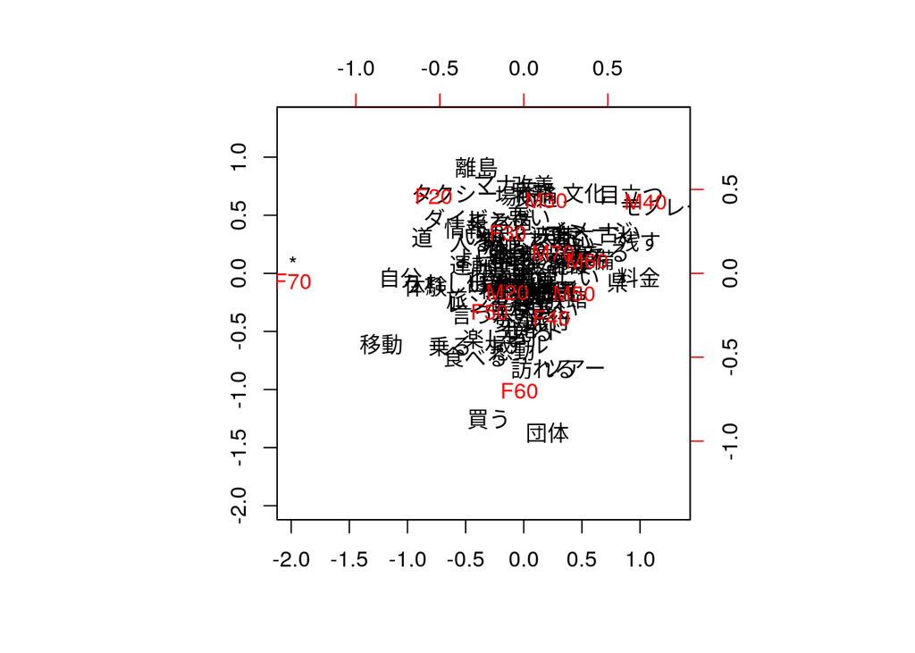

```r
FMCA <- MASS::corresp(FM4, nf=2)
biplot(FMCA)
```

## Topic Models

考え方：

1. テキストにはトピックが複数ある
2. テキストのテーマによってトピックの現れ方が違う
3. トピックを構成する単語の集合がある
4. そこでテキストを分析し、出現する単語がどのようなトピックを表現しているか調べる
5. また個々のテキストについては、これらのトピックのうち、どれが強く反映されているかを確かめる

歴代首相演説のトピックを探る。 演説テーマを浮き彫りにする。あるいは、時ごとの特徴を推定する。

### データの準備

作業手順：

1. 解凍したフォルダにある歴代首相の国会演説を読み込んで、頻度表を作成する。ただし名詞と形容詞にしぼり、かつ頻度が3以上のものに限定する`docDF`
2. サイズ（次元`dim`）を確認
3. 品詞細分類で絞り込む(`fliter`)
4. 生成されたデータの整合性を`duplicate`, `which` などで確認

### まず歴代首相演説全体を読み込んでデータ化する

```r
# いずれか１行を実行
# Mac/Linux
prime <- docDF("data/prime/utf8", type = 1, pos = c("名詞","形容詞"), minFreq = 3)
# Windows
prime <- docDF("data/prime/sjis", type = 1, pos = c("名詞","形容詞"), minFreq = 3)
```

[output not shown]

[output cut: 29 more lines]

[output not shown]

```r
# 次元（テキスト数と単語数）を確認
dim(prime)
```

```
## [1] 3213   85
```

```r
# 品詞細分類で絞り込んだ結果を別名(prime2)で保存
prime2 <- prime %>% filter(POS2 %in% c("一般","自立"))
# 次元（テキスト数と単語数）を再確認
dim(prime2)
```

```
## [1] 1555   85
```

```r
## 重複がないか確認。トピックモデルを適用するには文書単語行列に変換する必要があるが
## 重複があるとエラーになってしまう
##（同一の単語が文脈によっては異なる品詞・再分類が異なるため、別々にカウントされている場合がある
## たとえば助詞「が」の細分類は複数ありうる）
prime2$TERM %>% duplicated() %>% which()
```

```
## integer(0)
```

### データの整形

1. やや複雑な文字列、データ処理に必要な拡張機能を用意`library(stringr);library(magrittr)`
2. トピックモデルは数値処理を行うので、データの数値以外（つまり単語や品詞の情報）は分けておく`select(-c(TERM:POS2))`
3. 取り除けた単語一覧リストを、行の名前として保存`rownames`
4. ファイル名が長いので切り詰める`str_replace("_general-policy-speech.txt", "")` `str_replace("(\\d{4})\\d{4}_(\\d{3})", "\\1_\\2")`
5. いったんデータを確認(`View`)

```r
## データを分析に向いた形式に整える
library(stringr)
library(magrittr)
## 数値列だけを取り出して別名(prime3)で保存
prime3 <-  prime2 %>% select(-c(TERM:POS2))
## 行名に形態素解析の結果を設定
rownames(prime3) <- prime2$TERM
## 列名は短縮化
colnames(prime3)  %<>% str_replace("_general-policy-speech.txt", "")
colnames(prime3)  %<>% str_replace("(\\d{4})\\d{4}_(\\d{3})", "\\1_\\2")
# 確認
prime3 %>% head() #%>% View()
```

```
##          19531130_18_yoshida-shigeru 19541130_20_yoshida-shigeru
## あきらめ                           0                           0
## あと                               0                           0
## あらわれ                           0                           0
## あり方                             0                           0
## いい                               0                           0
## いかん                             0                           0
##          19551202_23_hatoyama-ichiro 19561116_25_hatoyama-ichiro
## あきらめ                           0                           0
## あと                               0                           0
## あらわれ                           0                           0
## あり方                             0                           0
## いい                               0                           0
## いかん                             0                           0
##          19570227_26_kishi-nobusuke 19590625_32_kishi-nobusuke
## あきらめ                          0                          0
## あと                              0                          0
## あらわれ                          0                          0
## あり方                            0                          0
## いい                              0                          0
## いかん                            0                          0
##          19601212_37_ikeda-hayato 19620810_41_ikeda-hayato
## あきらめ                        0                        0
## あと                            1                        0
## あらわれ                        0                        0
## あり方                          1                        0
## いい                            0                        0
## いかん                          0                        0
##          19621210_42_ikeda-hayato 19631018_44_ikeda-hayato
## あきらめ                        0                        0
## あと                            0                        0
## あらわれ                        0                        0
## あり方                          0                        0
## いい                            0                        0
## いかん                          0                        0
##          19631210_45_ikeda-hayato 19641121_47_sato-eisaku
## あきらめ                        0                       0
## あと                            2                       0
## あらわれ                        0                       0
## あり方                          0                       0
```

[output cut: 218 more lines]

```
## いかん                    0                       0
##          2011_179_noda-yoshihiko 2012_181_noda-yoshihiko
## あきらめ                       0                       0
## あと                           0                       0
## あらわれ                       0                       0
## あり方                         2                       2
## いい                           1                       0
## いかん                         0                       0
##          2013_183_abe-shinzo 2013_185_abe-shinzo 2014_187_abe-shinzo
## あきらめ                   0                   0                   0
## あと                       0                   0                   0
## あらわれ                   0                   0                   0
## あり方                     0                   0                   0
## いい                       0                   0                   0
## いかん                     0                   0                   0
```

### 文書単語行列にもとづくトピックモデルを適用

1. トピックモデルを実行するために必要な機能呼び出し`library(tm);library(topicmodels)`
2. 用意したデータを文書単語行列に変換する`as.DocumentTermMatrix`
3. 一般には文書の長さの違いが影響しないよう標準化する（ただし今回は単純頻度のまま`weighting = weightTf`）
4. データをさらにトピックモデルに適切なフォーマットに変換する`dtm2ldaformat`

```r
library(tm)# install.packages("tm")#でインストールしておく
library(topicmodels)# install.packages("topicmodels")#でインストールしておく
## 文書単語行列に変換
prime3a <- prime3 %>% t() %>%  as.DocumentTermMatrix(weighting = weightTf)
prime4  <- dtm2ldaformat(prime3a)
```

1. トピックモデルを実行するための拡張機能を準備`library(lda)`
2. 乱数を設定`set.seed`。これにより同じ結果を繰り返し再現できる
3. トピックの数を指定する。これは分析者が決める `K <- 5`
4. 実際に分析する（やや時間がかかる）`lda.collapsed.gibbs.sampler`

```r
library(lda)# install.packages("lda")
set.seed(123)
K <- 5
result <- lda.collapsed.gibbs.sampler(prime4$documents, K = K,
            prime4$vocab, 25, 0.1, 0.1, compute.log.likelihood=TRUE)
```

### 結果確認

結果から5つのトピックそれぞれで特徴的な語を１０個表示

```r
top.topic.words(result$topics, 10, by.score=TRUE)
```

```
##       [,1]     [,2]   [,3]   [,4]     [,5]
##  [1,] "社会"   "状況" "政治" "わが国" "国民"
##  [2,] "世界"   "企業" "地域" "経済"   "政府"
##  [3,] "経済"   "課題" "国民" "物価"   "行政"
##  [4,] "我が国" "戦略" "皆様" "政府"   "国際"
##  [5,] "財政"   "事業" "世紀" "両国"   "環境"
##  [6,] "基本"   "法案" "内閣" "友好"   "地方"
##  [7,] "新しい" "民間" "政策" "諸国"   "時代"
##  [8,] "構造"   "年金" "国"   "国際"   "体制"
##  [9,] "産業"   "未来" "方々" "企業"   "金融"
## [10,] "責任"   "分野" "制度" "情勢"   "厳しい"
```

### グラフ

可視化したいが、すべての総理大臣演説をグラフ化すると混雑するので、 小泉、鳩山、野田、安倍氏らの演説にしぼってトピックを確認

1. データから4人の首相演説を抽出`str_subset`、連番を確認した表を作成しておく`cbind`

```r
# 下準備
prime5 <- rownames(prime3a) %>% str_subset("koizumi|hatoyama|noda|abe")
prime5
```

```
##  [1] "19551202_23_hatoyama-ichiro" "19561116_25_hatoyama-ichiro"
##  [3] "2001_151_koizumi-jyunichiro" "2001_153_koizumi-jyunichiro"
##  [5] "2002_155_koizumi-jyunichiro" "2003_157_koizumi-jyunichiro"
##  [7] "2004_161_koizumi-jyunichiro" "2005_163_koizumi-jyunichiro"
##  [9] "2006_165_abe-shinzo"         "2007_168_abe-shinzo"
## [11] "2009_173_hatoyama-yukio"     "2011_178_noda-yoshihiko"
## [13] "2011_179_noda-yoshihiko"     "2012_181_noda-yoshihiko"
## [15] "2013_183_abe-shinzo"         "2013_185_abe-shinzo"
## [17] "2014_187_abe-shinzo"
```

```r
prime6 <- rownames(prime3a) %>%
        str_detect("koizumi|hatoyama|noda|abe") %>% which
prime6
```

```
##  [1]  3  4 64 65 66 67 68 69 70 71 74 77 78 79 80 81 82
```

```r
cbind(prime6, prime5)
```

```
##       prime6 prime5
##  [1,] "3"    "19551202_23_hatoyama-ichiro"
##  [2,] "4"    "19561116_25_hatoyama-ichiro"
##  [3,] "64"   "2001_151_koizumi-jyunichiro"
##  [4,] "65"   "2001_153_koizumi-jyunichiro"
##  [5,] "66"   "2002_155_koizumi-jyunichiro"
##  [6,] "67"   "2003_157_koizumi-jyunichiro"
##  [7,] "68"   "2004_161_koizumi-jyunichiro"
##  [8,] "69"   "2005_163_koizumi-jyunichiro"
##  [9,] "70"   "2006_165_abe-shinzo"
## [10,] "71"   "2007_168_abe-shinzo"
## [11,] "74"   "2009_173_hatoyama-yukio"
## [12,] "77"   "2011_178_noda-yoshihiko"
## [13,] "78"   "2011_179_noda-yoshihiko"
## [14,] "79"   "2012_181_noda-yoshihiko"
## [15,] "80"   "2013_183_abe-shinzo"
## [16,] "81"   "2013_185_abe-shinzo"
## [17,] "82"   "2014_187_abe-shinzo"
```

```r
## それぞれの演説で５つのトピックが占める割合を計算
options(digits = 3)
topic.proportions <- t(result$document_sums) / colSums(result$document_sums)
## 対象とする所信表明演説を抽出
ministers  <- topic.proportions [c(64, 74, 77, 80), ]
ministers
```

```
##       [,1]  [,2]  [,3]    [,4]  [,5]
## [1,] 0.381 0.161 0.200 0.00166 0.257
## [2,] 0.218 0.208 0.395 0.00166 0.177
## [3,] 0.206 0.376 0.275 0.00000 0.144
## [4,] 0.280 0.378 0.171 0.00000 0.171
```

```r
# ministers %>% rowSums()

## 計算結果をデータフレームに変換し列名を設定
ministersDF <- as.data.frame(ministers) %>%
                 set_names(paste0("topic", 1:5)) %>%
                   ## num という列を追加
  mutate(PM = c("小泉", "鳩山", "野田", "安倍"))

ministersDF
```

```
##   topic1 topic2 topic3  topic4 topic5   PM
## 1  0.381  0.161  0.200 0.00166  0.257 小泉
## 2  0.218  0.208  0.395 0.00166  0.177 鳩山
## 3  0.206  0.376  0.275 0.00000  0.144 野田
## 4  0.280  0.378  0.171 0.00000  0.171 安倍
```

グラフ用にさらに整えて

```r
library(tidyr)
```

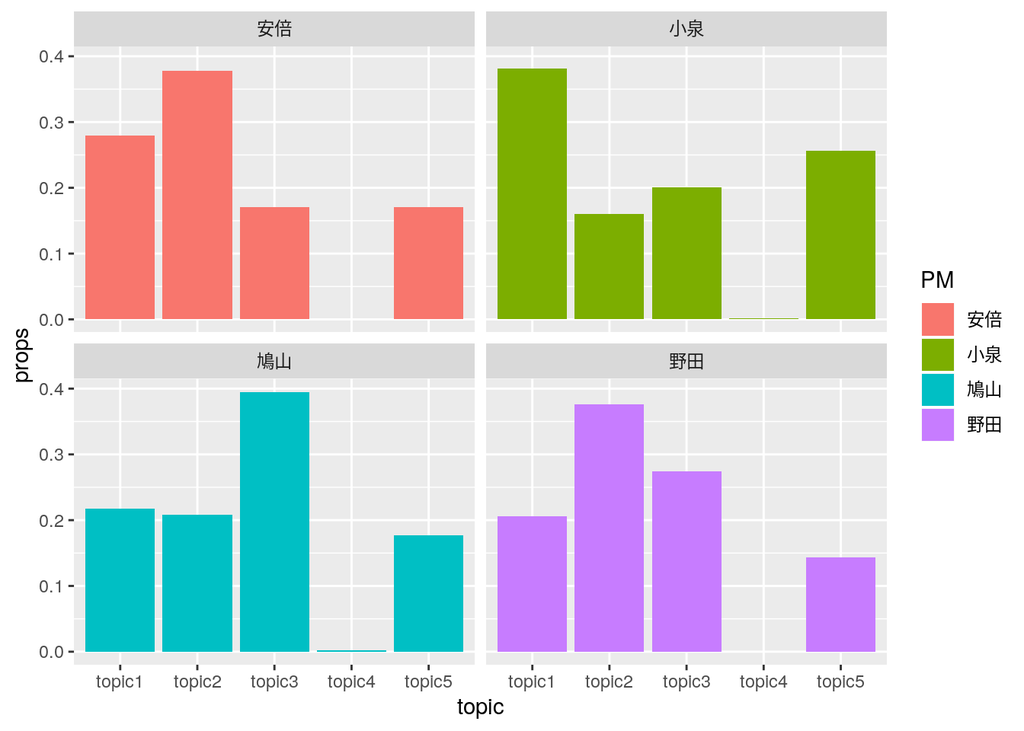

```r
ministersDF <- ministersDF %>%
                   gather(key = topic, value = props, -PM)
library(ggplot2)
ministersDF %>% ggplot(aes(x = topic, y = props, fill = PM)) + geom_bar(stat = "identity") + facet_wrap(~PM)
```

```r
# Macの場合は + theme_gray (base_family = "HiraKakuPro-W3")#を追加
```

## センチメント分析

1. 感情スコアを振ったデータベースをダウンロードしてデータとして利用`read.table`

```r
dic <- read.table("http://www.lr.pi.titech.ac.jp/~takamura/pubs/pn_ja.dic",
   sep = ":", stringsAsFactors = FALSE, fileEncoding = "CP932"
   , encoding = "UTF-8"# Windowsでこの行は不要なので行頭に半角#を追記
   )
dic  %>% head(15)# 冒頭15行を確認
```

```
##          V1       V2     V3       V4
## 1    優れる すぐれる   動詞 1.000000
## 2      良い     よい 形容詞 0.999995
## 3      喜ぶ よろこぶ   動詞 0.999979
## 4    褒める   ほめる   動詞 0.999979
## 5  めでたい めでたい 形容詞 0.999645
## 6      賢い かしこい 形容詞 0.999486
## 7      善い     いい 形容詞 0.999314
## 8      適す   てきす   動詞 0.999295
## 9      天晴 あっぱれ   名詞 0.999267
## 10     祝う   いわう   動詞 0.999122
## 11     功績 こうせき   名詞 0.999104
## 12       賞   しょう   名詞 0.998943
## 13   嬉しい うれしい 形容詞 0.998871
## 14     喜び よろこび   名詞 0.998861
## 15     才知   さいち   名詞 0.998771
```

```r
dic <- dic %>% select(TERM = V1, V4)
```

## テキスト全体のポジネガ判定

例文『走れメロス』

1. メロスの冒頭を`merosu`という名前のデータフレーム(`data.frame`)として保存。このデータは列が1個、行も1個だけ
2. このデータの`X`列を形態素解析にかけてデータ化する`docDF`
3. ただし結果から利用するのは`TERM`列と`Row1`列(行番号に相当)だけ
4. これを`res2`という名前で保存

```r
merosu <- data_frame(X = "メロスは激怒した。必ず、かの 邪智暴虐の王を除かなければならぬと決意した。メロスには政治がわからぬ。メロスは、村の牧人である。笛を吹き、羊と遊んで暮して来た。けれども邪悪に対しては、人一倍に敏感であった。")
# 形態素解析を適用してデータ化、利用するのは単語列（TERM)とファイル名列（この場合はRow1)の2つ
res2 <- docDF(merosu, "X", type = 1, pos =c("名詞", "形容詞", "動詞")) %>% select(TERM , Row1)
```

```
## number of extracted terms = 22
## now making a data frame. wait a while!
```

```r
res2 %>% head()
```

```
##     TERM Row1
## 1   する    2
## 2   なる    1
## 3 わかる    1
## 4 メロス    3
## 5 人一倍    1
## 6   吹く    1
```

形態素解析データの結果と、感情辞書データを結合する

1. `res2` データに対して
2. ％＞％
3. `dic` データとの結合を行う(`left_jooin`)
4. その結果を`res3`という名前で保存
5. 冒頭部分を確認(`head`)

```r
res3 <- res2 %>% left_join(dic,by = "TERM")
res3 %>% head()
```

```
##     TERM Row1         V4
## 1   する    2         NA
## 2   なる    1         NA
## 3 わかる    1         NA
## 4 メロス    3         NA
## 5 人一倍    1 -0.0566489
## 6   吹く    1 -0.9543540
```

`res3`データから、作品全体（今は冒頭数行だけなのだが）を通じての感情値(`V4`)の合計(`sum`)を出して要約(`summarise`)とする

```r
res3 %>% summarise(sum(V4, na.rm = TRUE))
```

```
##   sum(V4, na.rm = TRUE)
## 1             -10.76606
```

### 同じことを宮沢賢治『注文の多い料理店』冒頭で試す

```r
miyazawa <- data_frame(X = "二人の若い紳士が、すっかりイギリスの兵隊のかたちをして、ぴかぴかする鉄砲をかついで、白熊のような犬を二疋つれて、だいぶ山奥の、木の葉のかさかさしたとこを、こんなことを云いながら、あるいておりました。")
miyazawa_res <- docDF(miyazawa, "X", type = 1, pos =c("名詞", "形容詞", "動詞")) %>%  select(TERM , Row1)
```

```
## number of extracted terms = 22
## now making a data frame. wait a while!
```

```r
miyazawa_res %>% left_join(dic,by = "TERM") %>% summarise(sum(V4, na.rm = TRUE))
```

```
##   sum(V4, na.rm = TRUE)
## 1             -1.812846
```

## 「注文の多い料理店」全文の時系列感情分析

テキストの流れの中で感情値の変遷を時系列としてみる。平たく言えば、起承転結のようなものが可視化される。

そのためには、テキストを文章ごとに区切り、それぞれの文章ごとに出現する単語と、その感情値をデータとしてまとめておく必要がある。

分析手順：最初にデータの整形

1. テキストデータの取得（‘Aozora`)
2. テキストを文章に区切る。ここでは句点で区切る`str_split(pattern = "(?<=。)")`
3. 行頭の全角スペースを削除`str_replace_all("　", "")`
4. 鍵カッコも削除`str_replace_all("「|」", "")`

```r
source("http://rmecab.jp/R/Aozora.R")# 青空文庫ダウンロード解析用機能の取得
kenji <- Aozora("https://www.aozora.gr.jp/cards/000081/files/43754_ruby_17594.zip")
```

```
## example: folder_name <- Aozora('http://www.aozora.gr.jp/cards/000081/files/462_ruby_716.zip')
```

```r
chumon <- readLines(kenji)
chumon[1:5]
```

```
## [1] "注文の多い料理店"
## [2] "宮沢賢治"
## [3] ""
## [4] ""
## [5] "　二人の若い紳士が、すっかりイギリスの兵隊のかたちをして、ぴかぴかする鉄砲をかついで、白熊のような犬を二疋つれて、だいぶ山奥の、木の葉のかさかさしたとこを、こんなことを云いながら、あるいておりました。"
```

```r
##　いくつかのパラグラフに分かれてはいるが、
library(stringr)
## タイトルと作家名を除いて、いったん、すべて結合
chumon <- chumon %>% replace(1:2, "")  %>% str_c(collapse = "") #
# ちなみに文字数を確認
chumon %>% nchar()
```

```
## [1] 5466
```

```r
## 最初の一文を確認
chumon %>% str_extract("^[\\P{Hiragana}\\P{Katakana}\\P{Han}]*?。")
```

```
## [1] "　二人の若い紳士が、すっかりイギリスの兵隊のかたちをして、ぴかぴかする鉄砲をかついで、白熊のような犬を二疋つれて、だいぶ山奥の、木の葉のかさかさしたとこを、こんなことを云いながら、あるいておりました。"
```

```r
## 行頭の全角スペースも削除し文章単位に分割する。もっとも単純な方法は句点での区切る
sentence <- chumon %>% str_replace_all("　", "") %>% str_split(pattern =  "(?<=。)") %>% unlist()
# sentence %>% head()
## カギ括弧も削除
sentence <- sentence %>%  str_replace_all("　", "") %>%  str_replace_all("「|」", "")
## 空のレコード("")が残っていればこれを削除する(""ではない行 (S != "") だけを残す)
sentence <- sentence[sentence != ""]
# 結果を確認
sentence %>% head()
```

```
## [1] "二人の若い紳士が、すっかりイギリスの兵隊のかたちをして、ぴかぴかする鉄砲をかついで、白熊のような犬を二疋つれて、だいぶ山奥の、木の葉のかさかさしたとこを、こんなことを云いながら、あるいておりました。"
## [2] "ぜんたい、ここらの山は怪しからんね。"
## [3] "鳥も獣も一疋も居やがらん。"
## [4] "なんでも構わないから、早くタンタアーンと、やって見たいもんだなあ。"
## [5] "鹿の黄いろな横っ腹なんぞに、二三発お見舞もうしたら、ずいぶん痛快だろうねえ。"
## [6] "くるくるまわって、それからどたっと倒れるだろうねえ。"
```

文章ごとに感情値を算出する

1. 文章の最初から最後まで連番をふる
2. それぞれの文章を単語に分割
3. 単語と出現した行番号からなるデータフレームを作成

```r
# 文章番号を振っておく
sentence <- data_frame(S = sentence, N = (1:length(sentence)))
# データを確認
sentence %>% head()
```

```
## # A tibble: 6 x 2
##   S                                                                       N
##   <chr>                                                               <int>
## 1 二人の若い紳士が、すっかりイギリスの兵隊のかたちをして、ぴかぴかする鉄砲をかついで、白熊のような犬を二疋つれて、だいぶ山奥の、木の葉…     1
## 2 ぜんたい、ここらの山は怪しからんね。                                    2
## 3 鳥も獣も一疋も居やがらん。                                              3
## 4 なんでも構わないから、早くタンタアーンと、やって見たいもんだなあ。      4
## 5 鹿の黄いろな横っ腹なんぞに、二三発お見舞もうしたら、ずいぶん痛快だろうねえ。…     5
## 6 くるくるまわって、それからどたっと倒れるだろうねえ。                    6
```

文章ごとに形態素解析を実施し、その連番とともにセットで保存する処理を行う（関数型プログラミングという、かなり高度な方法を使っています）

```r
library(purrr) # install.packages("purrr", depend = TRUE)
```

```r
## ここは文章ごとに形態素解析にかけて、その結果をまとめる処理
funs <- function(x, y){
     x <- unlist(RMeCabC(x, 1))
   data_frame(TERM = x, N = y)
}

x <- map2_dfr(sentence$S, sentence$N,
 ~ funs(..1, ..2)
)
# 単語と出現した文章番号がペアになったデータが生成される
x
```

```
## # A tibble: 3,219 x 2
##    TERM         N
##    <chr>    <int>
##  1 二           1
##  2 人           1
##  3 の           1
##  4 若い         1
##  5 紳士         1
##  6 が           1
##  7 、           1
##  8 すっかり     1
##  9 イギリス     1
## 10 の           1
## # … with 3,209 more rows
```

1. 作成したデータを感情辞書と結合する(`left_join`)
2. 文章番号(`N`)ごとに(`group_by`)感情値(`v4`)の合計(`sum`)を求めて`EM`列とする
3. またこれを要約する(`summarise`)。ただし感情値が割り当てられていない単語もあるので、それは無視する(`na.rm = TRUE`)

```r
xx <- x %>% left_join(dic)
yy <- xx %>% group_by(N) %>% summarise(EM = sum(V4, na.rm = TRUE))
## EM列を要約してみる
yy %>% select(EM) %>% summary()
```

```
##        EM
##  Min.   :-17.3252
##  1st Qu.: -4.1487
##  Median : -1.9665
##  Mean   : -2.6892
##  3rd Qu.: -0.6296
##  Max.   :  1.1676
```

```r
## Min. は最小値 Medianは中央値、Meanが平均値、Maxは最大値。1st Qu.と3rd Qu.は第一四分位と第三四分位
```

## グラフ化する

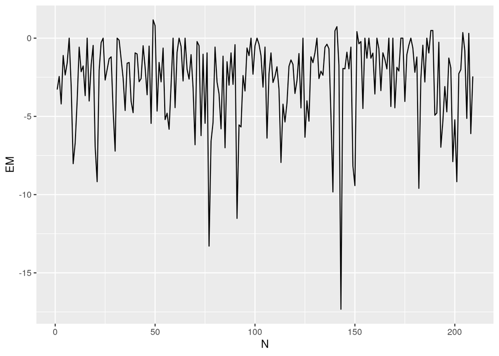

```r
yy %>% ggplot(aes(x = N, y = EM)) + geom_line()
```

全体の平均値が０として、グラフの０より上はポジティブな描写（文章表現）、0より下はネガティブな描写（文章表現）と判断できるように調整する（文章ごとの感情値合計から、全体の平均値を引く）

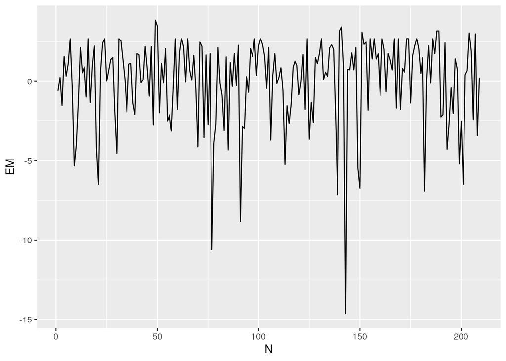

```r
yy %>% mutate(EM = EM - mean(EM)) %>% ggplot(aes(x = N, y = EM)) + geom_line()
```

```r
## yy %>% mutate(EM = scale(EM)) %>% ggplot(aes(x = N, y = EM)) + geom_line() #こちらでも良い
```

もっともネガティブだと判定された文書の連番から、実際にその文章を確認する

```r
yy %>% filter(EM == min(EM))
```

```
## # A tibble: 1 x 2
##       N    EM
##   <int> <dbl>
## 1   143 -17.3
```

```r
sentence[143,] %>% as.character()
```

```
## [1] "だからさ、西洋料理店というのは、ぼくの考えるところでは、西洋料理を、来た人にたべさせるのではなくて、来た人を西洋料理にして、食べてやる家とこういうことなんだ。"
## [2] "143"
```

もっともポジティブだと判定された文書の連番から、実際にその文章を確認する

```r
yy %>%  filter(EM == max(EM))
```

```
## # A tibble: 1 x 2
##       N    EM
##   <int> <dbl>
## 1    49  1.17
```

```r
sentence[49,] %>% as.character()
```

```
## [1] "ことに肥ったお方や若いお方は、大歓迎いたします二人は大歓迎というので、もう大よろこびです。"
## [2] "49"
```

### 文章ごとに感情値の合計を求めるのではなく、平均値になおして時系列グラフを描いてみる

```r
byMean <- xx %>% group_by(N) %>% summarise(EM = mean(V4, na.rm = TRUE))
byMean %>% select(EM) %>% summary()
```

```
##        EM
##  Min.   :-0.9999
##  1st Qu.:-0.6961
##  Median :-0.5770
##  Mean   :-0.5539
##  3rd Qu.:-0.4560
##  Max.   : 0.3967
##  NA's   :20
```

グラフ化する

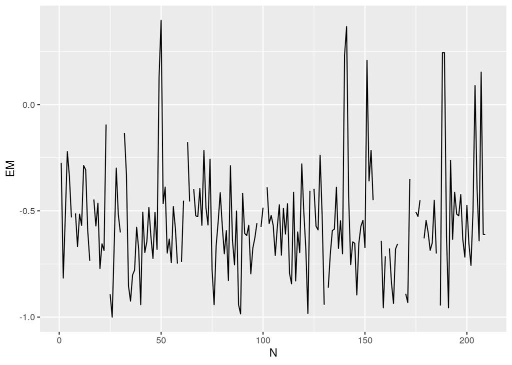

```r
byMean %>%  ggplot(aes(x = N, y = EM)) + geom_line()
```

もっともネガティブだと判定された文書の連番から、実際にその文章を確認する

```r
byMean %>% filter(EM == min(EM, na.rm = TRUE))
```

```
## # A tibble: 1 x 2
##       N     EM
##   <int>  <dbl>
## 1    26 -1.000
```

```r
sentence[26,] %>% as.character()
```

```
## [1] "あるきたくないよ。" "26"
```

```r
byMean %>% filter(EM == max(EM, na.rm = TRUE))
```

```
## # A tibble: 1 x 2
##       N    EM
##   <int> <dbl>
## 1    50 0.397
```

```r
sentence[50,] %>% as.character()
```

```
## [1] "君、ぼくらは大歓迎にあたっているのだ。"
## [2] "50"
```